# Issue Agendas in the 2022 Ontario Election

Simon Kiss

2022-12-08

This is a test blog post. Hello.

One of the perplexing things about many of the provincial elections that have occurred in the several provincial elections that have occurred since the pandemic is that most of the provincial governments to have faced the electorate have been reelected. Specifically, the Ontario Progressive Conservatives, British Columbia NDP, Coalition Avenir de Quebec and the New Brunswick Progressive Conservative governments were all re-elected. Only the Nova Scotia Liberal government was defeated.

It’s a pretty common criticism to see people express a bit of disbelief at this, with people wondering how voters could return governments who presided over such terrible times. In Ontario, at least, one reason might be that voters basically moved on to other issues, specifically inflation and the cost of living.

As part of our anlaysis, we’ve also been going over the media coverage of the campaign. Voters were clearly concerned about the cost of living and inflation, more so than COVID. This actually fits with much of the literature on agenda-setting which suggests that, as much as the news media do have power to get people to think about certain things, that power is limited to issues which are remote from people’s lives. An example here is something like the environment. People don’t really experience climate change in the way they experience inflation or unemployment; any effects of climate change are too diffuse and downstream from anything we do to be really perceived as anything other than a particularly hot, cold or rainy day. But inflation is different.

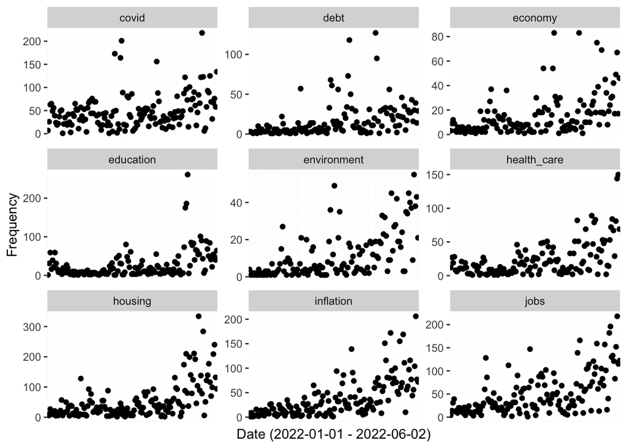